# GGG 201a Intro to R 1 Notes

Taylor Reiter

11/29/2018

This is an R script. It keeps track of our code. We have written this script so that it is completely repeatable. Even the download links to get the data we will be using are present so anyone could pick of this script and run it.

Our script starts out like this:

```r
##############
# 11/30/18
# GGG 201a
# Intro to R 1
##############

# This lesson is adapted from:
# http://evomics.org/learning/programming/introduction-to-r/
# this lesson material is available at:
# https://github.com/ngs-docs/2018-ggg201a
```

Each line begins with a `#`. Any line in a script that begins with a `#` demarcates it as a comment. Comments are a useful way to give context to your code. They remind other people (including your future self) what the code does, can give attribution to sources, and help with organization.

Next, we load package libraries that allow R to do new things

```r
library(tidyverse)
library(vegan)
```

```r
library(pheatmap)
```

`url` is an object. We assign it some value, and that value is remembered by R. Objects have different types, and you will see a few of those types today.

`url` is currently a `character` vector. We know it is a character because it is in quotes. Vectors are objects that only have lengths. They can have a length of one, or can be really long. Our vector has length one, since it only has one character string in it.

`()` indicate that something is a `function`. That means that it **does** something. Here, the function takes a url, downloads it from the internet, and saves it to a destination file on our local computers. This function takes the `arguments` `url` and `destfile`.

```r
# Download data files
url <- "https://raw.githubusercontent.com/ngs-docs/2018-ggg201a/master/data/myoviridae.csv"
download.file(url = url, destfile = "myoviridae.csv")
```

To bring the data into R, we use the function `read.csv`. We give it the file name on our computer, and in this case, we say that we would like the first column to contain our rownames.

rownames must be unique. Sometimes they can be handy to keep track of sample or gene information when a function requires only numeric data. We will see an example of this later.

```r
# Read data into R
myov <- read.csv(file = "myoviridae.csv", row.names = 1)
```

We also have metadata to accompany our count file. We can download it and read into R the same way we did before.

```r
# Download metadata file
url <- "https://raw.githubusercontent.com/ngs-docs/2018-ggg201a/master/data/metadata.csv"
download.file(url = url, destfile = "metadata.csv")
```

You can see from the above code that we define `url` a second time. When you use to `<-` assignment arrow in R, you overwrite the object if it already exists and give it a new value.

```r
# Read data into R
metadata <- read.csv("metadata.csv")
```

When we take a look at this data, we see that it contains information about subject age and disease state.

```r
# look at the top of the file
head(metadata)
```

```
##                   X Diagnosis Sex Age
## 1 16120_Chi_Healthy   Healthy   F  44
## 2 16119_Chi_Healthy   Healthy   F  59
## 3 16118_Chi_Healthy   Healthy   F  69
## 4 16117_Chi_Healthy   Healthy   M  50
## 5 16116_Chi_Healthy   Healthy   M  47
## 6 16115_Chi_Healthy   Healthy   M  37
```

```r
summary(metadata)
```

```
##                  X        Diagnosis    Sex          Age
##  16098_Chi_Healthy: 1   Healthy:22   F   :13   Min.   :25.00
##  16099_Chi_Healthy: 1   Sick   : 7   M   :15   1st Qu.:37.00
##  16100_Chi_Healthy: 1                NA's: 1   Median :45.50
##  16101_Chi_Healthy: 1                          Mean   :46.39
##  16102_Chi_Healthy: 1                          3rd Qu.:55.25
##  16103_Chi_Healthy: 1                          Max.   :69.00
##  (Other)          :23                          NA's   :1
```

We can also use the square brackets `[]` to subset our `data.frame` in a specific way.

```r
# look at the first column of the metadata file
metadata[ , 1]
```

```
##  [1] 16120_Chi_Healthy 16119_Chi_Healthy 16118_Chi_Healthy
##  [4] 16117_Chi_Healthy 16116_Chi_Healthy 16115_Chi_Healthy
##  [7] 16114_Chi_Healthy 16113_Chi_Healthy 16112_Chi_Healthy
## [10] 16111_Chi_Healthy 16110_Chi_Healthy 16108_Chi_Healthy
## [13] 16107_Chi_Healthy 16106_Chi_Healthy 16105_Chi_Healthy
## [16] 16104_Chi_Healthy 16103_Chi_Healthy 16102_Chi_Healthy
## [19] 16101_Chi_Healthy 16100_Chi_Healthy 16099_Chi_Healthy
## [22] 16098_Chi_Healthy 2424_Chi_UC       2415_Chi_CD
## [25] 2414_Chi_CD       2413_Chi_CD       2412_Chi_CD
## [28] 2411_Chi_CD       2409_Chi_CD
## 29 Levels: 16098_Chi_Healthy 16099_Chi_Healthy ... 2424_Chi_UC
```

let’s take a look at `Age` between each dataset. We use ggplot2 to do this. ggplot2 uses layers to build a graph.

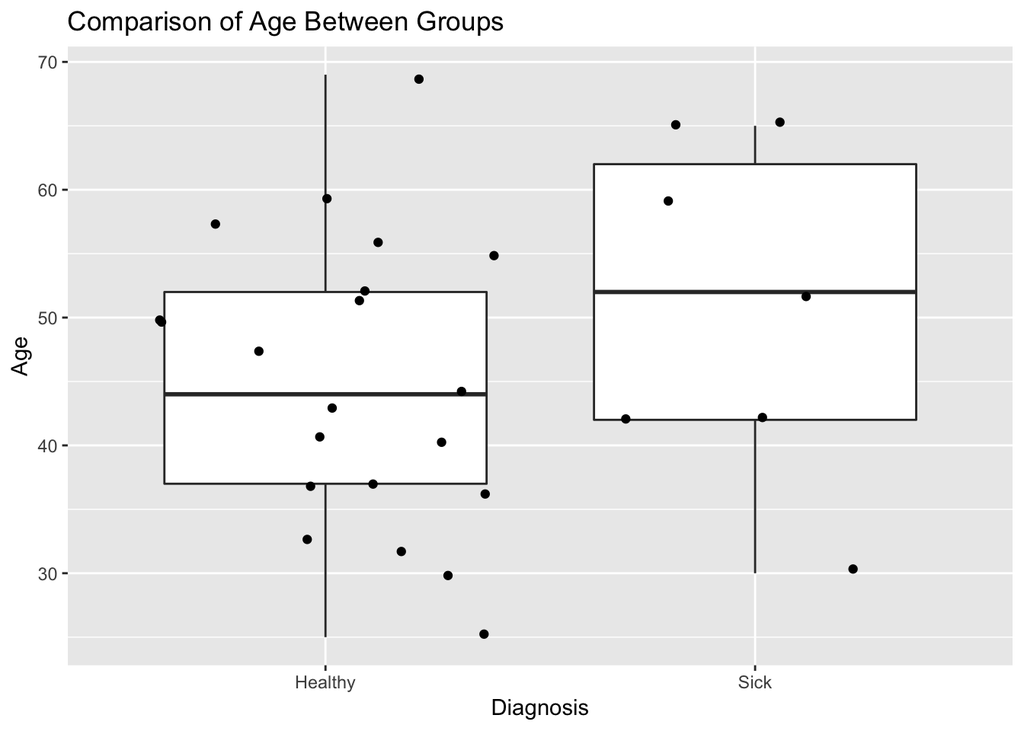

```r
# plot the age of healthy and sick patients
ggplot(data = metadata, aes(x = Diagnosis, y = Age)) +
  geom_boxplot() +
  geom_jitter() +
  ggtitle("Comparison of Age Between Groups")
```

Before looking at the count data, let’s transform it.

```r
# transform the count data
myov_total <- decostand(myov, method="total")
```

To see what the `decostand()` function does, check the help file.

```r
?decostand()
```

ggplot2 likes to have data in long form. We can transform our data with a few steps.

First, we have to move the rownames, which contain sample information, into a column. We’ll make a new dataframe to do this because we will still want to use the original dataframe later.

```r
# move the rownames into a column
myov_total_labeled <- myov_total
myov_total_labeled$X <- rownames(myov_total)
```

Next we will do the wide-to-long transformation with the function `gather()`

```r
# change the format of the count data
myov_long <- gather(data = myov_total_labeled, key = species, value = count, -X)
head(myov_long)
```

```
##                   X               species count
## 1 16099_Chi_Healthy Listeria_phage_LP.125     0
## 2 16100_Chi_Healthy Listeria_phage_LP.125     0
## 3 16101_Chi_Healthy Listeria_phage_LP.125     0
## 4 16102_Chi_Healthy Listeria_phage_LP.125     0
## 5 16103_Chi_Healthy Listeria_phage_LP.125     0
## 6 16104_Chi_Healthy Listeria_phage_LP.125     0
```

Then we’ll combine the long count data with metadata. This way we can add metadata information like disease state to our plot.

```r
# join the count data with metadata
all_data <- left_join(myov_long, metadata, by = "X")
```

There are a lot of species in our data. We can subsample to a smaller set of species using functiongs in dplyr.

```r
# pull out key species in myov data
key_species <- c("Tevenvirinae", "Punalikevirus", "Clostridium_phase_c.st", "PhiCD119likevirus")

key_species_data <- all_data %>%
                      filter(species %in% key_species)
```

Using our new dataframe, we can make a plot of a few species that interest us.

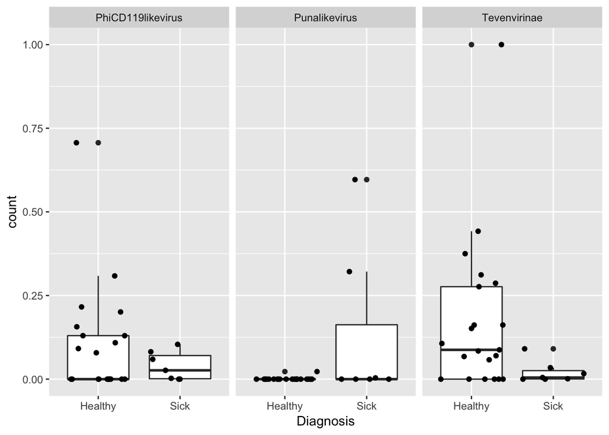

```r
# plot the abundances of key species in the myov object
ggplot(data = key_species_data, aes(x = Diagnosis, y = count)) +
  geom_boxplot() +
  geom_jitter() +
  facet_wrap(~ species)
```

To look at all species at once, we can plot a heatmap.

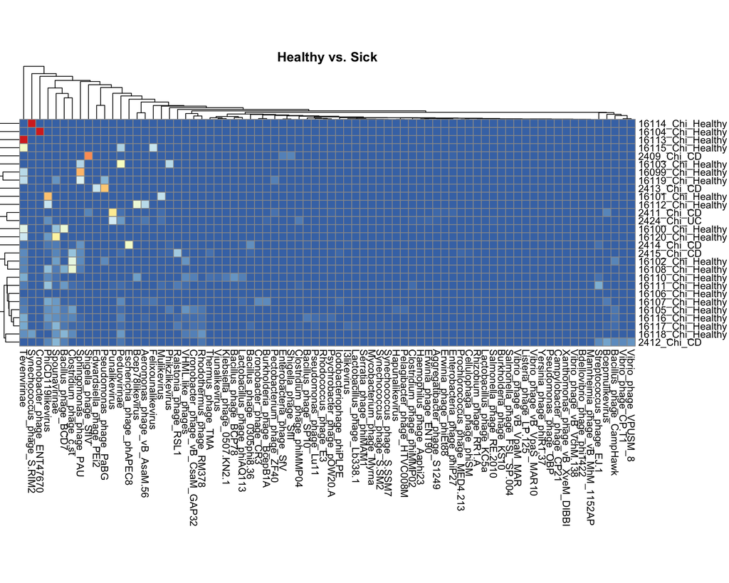

```r
# plot a heatmap of all species
plt <- pheatmap(myov_total, cellwidth=8, cellheight=8, main="Healthy vs. Sick")
```

Lastly, we may want to export one of our dataframes to a file to use later. We can do that with the `write.csv()` function.

```r
# export the transformed data that went into the heatmap
write.csv(myov_total, "myoviridae_total.csv", quote = F)
```